# Projet_TimeSeries

Fatimetou Haidara

2023-01-26

```r
#Loading the data
data <- read_excel("C:/Users/f_ati/Documents/Master2/Times series/Projet/Timeseries/Elec-train.xlsx")
data
```

```
## # A tibble: 4,603 × 3
##    Timestamp          `Power (kW)` `Temp (C°)`
##    <chr>                     <dbl>       <dbl>
##  1 40179.052083333336         165.        10.6
##  2 1/1/2010 1:30              152.        10.6
##  3 1/1/2010 1:45              147.        10.6
##  4 1/1/2010 2:00              154.        10.6
##  5 1/1/2010 2:15              154.        10.6
##  6 1/1/2010 2:30              159         10.6
##  7 1/1/2010 2:45              158.        10.6
##  8 1/1/2010 3:00              163.        10.6
##  9 1/1/2010 3:15              152.        10
## 10 1/1/2010 3:30              149.        10
## # … with 4,593 more rows
```

```r
#These quantities are measured every 15 minutes, 1h =60/15.
#from 1/1/2010 1:15 to 2/16/2010 23:45.
elec_power<-ts(data[1:4507,2],start=c(1,2),freq=60/15)
tail(elec_power)
```

```
##       Qtr1  Qtr2  Qtr3  Qtr4
## 1126             265.4 270.9
## 1127 276.2 192.7 187.1 149.5
```

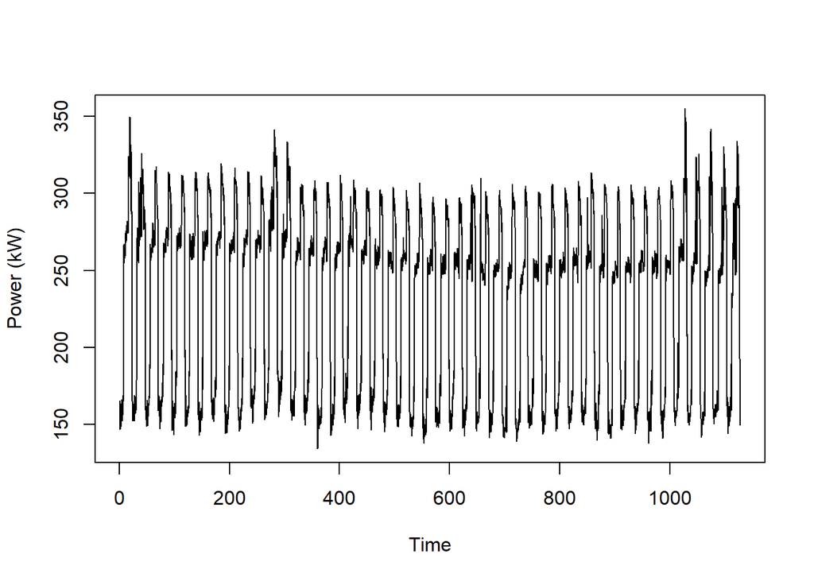

```r
plot(elec_power)
```

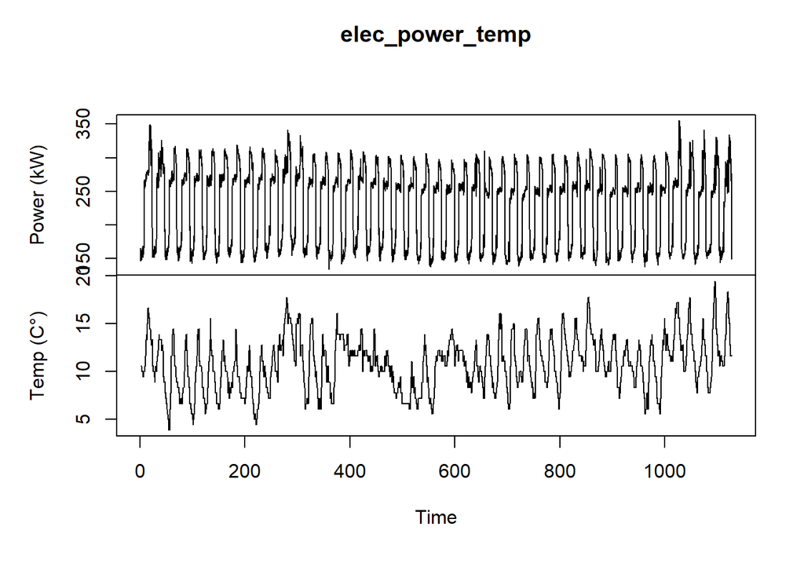

```r
elec_power_temp<-ts(data[1:4507,2:3],start=c(1,2),freq=4)
plot(elec_power_temp)
```

```r
mean(elec_power)
```

```
## [1] 231.5873
```

L’auto-corrélation nous montre qu’il y a un modèle saisionnier dans les données.

```r
tmp=acf(elec_power,type="cor",plot = FALSE)
tmp$acf[1:3,1,1]
```

```
## [1] 1.0000000 0.9641389 0.9317837
```

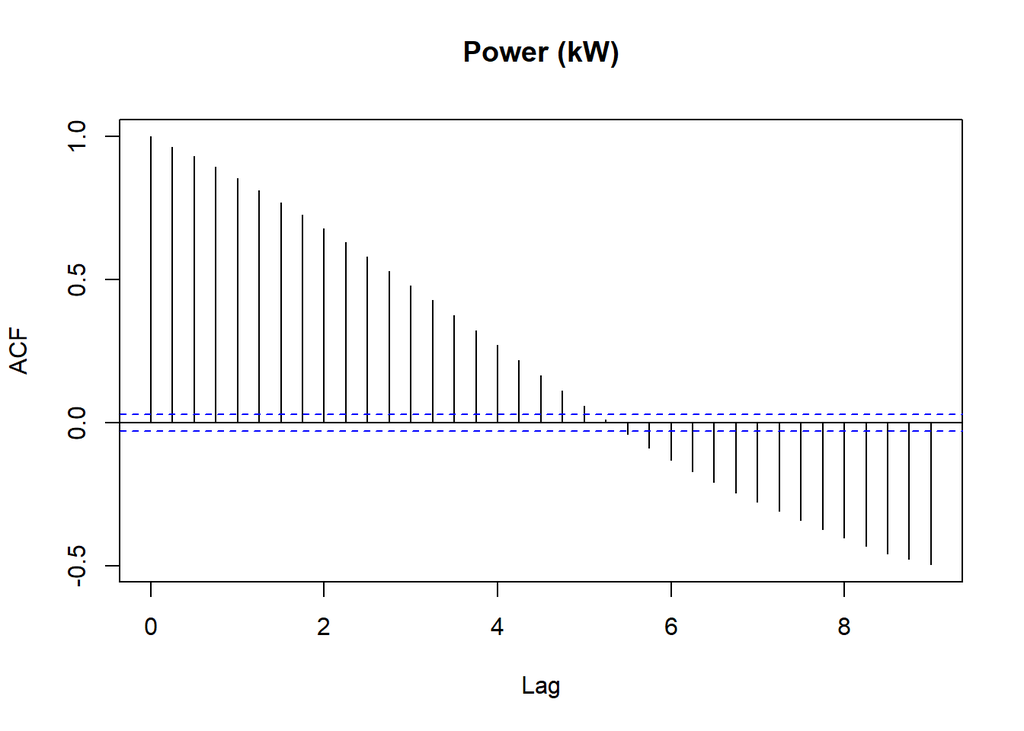

```r
plot(tmp)
```

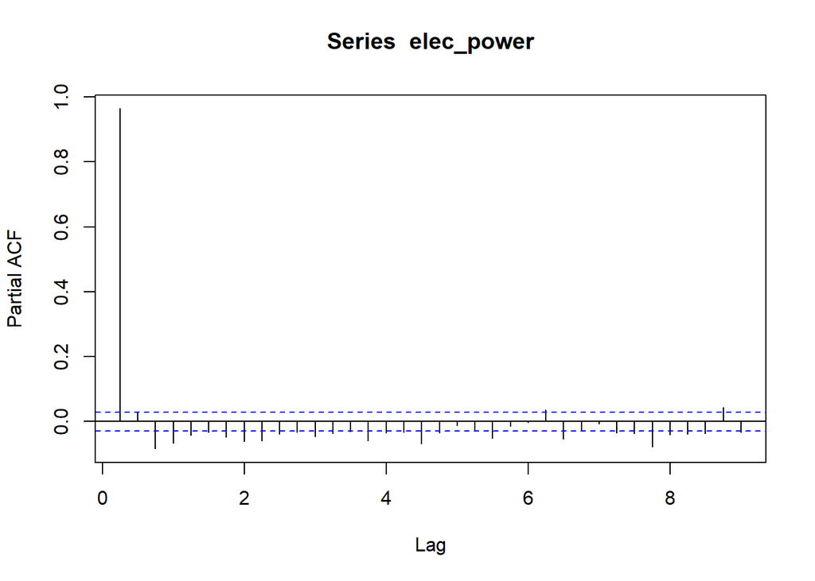

```r
pacf(elec_power)
```

# We split the serie into train and test

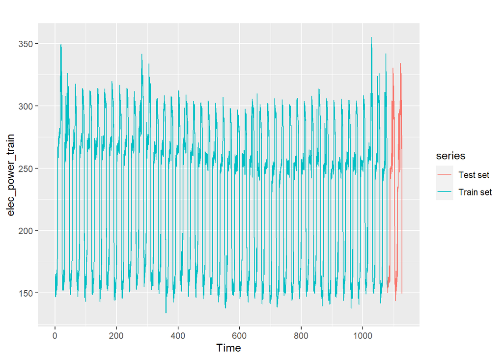

```r
#We need to make two sets of data: the train one (80%) and the test one (20%) in order to evaluate the model.
elec_power_train=head(elec_power,4315)
elec_power_test=tail(elec_power,192)
autoplot(elec_power_train,series="Train set")+
autolayer(elec_power_test,series='Test set')
```

########################### FORECAST ####################################

# On commence par les modèles qui ne tiennent pas compte des tendances saisonnières.

## Lissage exponentiel simple (SES)

La technique de lissage exponentiel simple est utilisée pour les données qui n’ont pas de tendance ou de modèle saisonnier.

```r
SES=ses(elec_power_train,h=192, alpha = .2)
round(accuracy(SES,elec_power_test),2)
```

```
##                 ME  RMSE   MAE   MPE  MAPE MASE ACF1 Theil's U
## Training set  0.04 27.11 16.09 -1.47  7.80 1.00 0.83        NA
## Test set     43.23 73.25 64.31 12.49 25.84 3.98 0.94      3.46
```

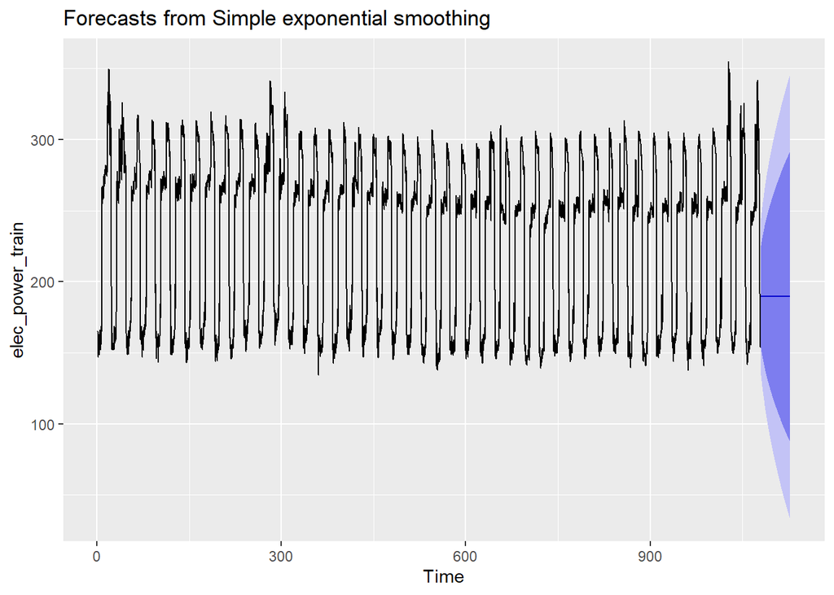

```r
autoplot(SES)
```

nous pouvons remarquer qu’une estimation plate est projetée vers l’avenir par notre modèle de prévision. Par conséquent, nous pouvons dire que d’après les données, il ne capture pas la tendance actuelle.

Par conséquent, pour corriger cela, nous utiliserons la fonction diff() pour supprimer la tendance des données.

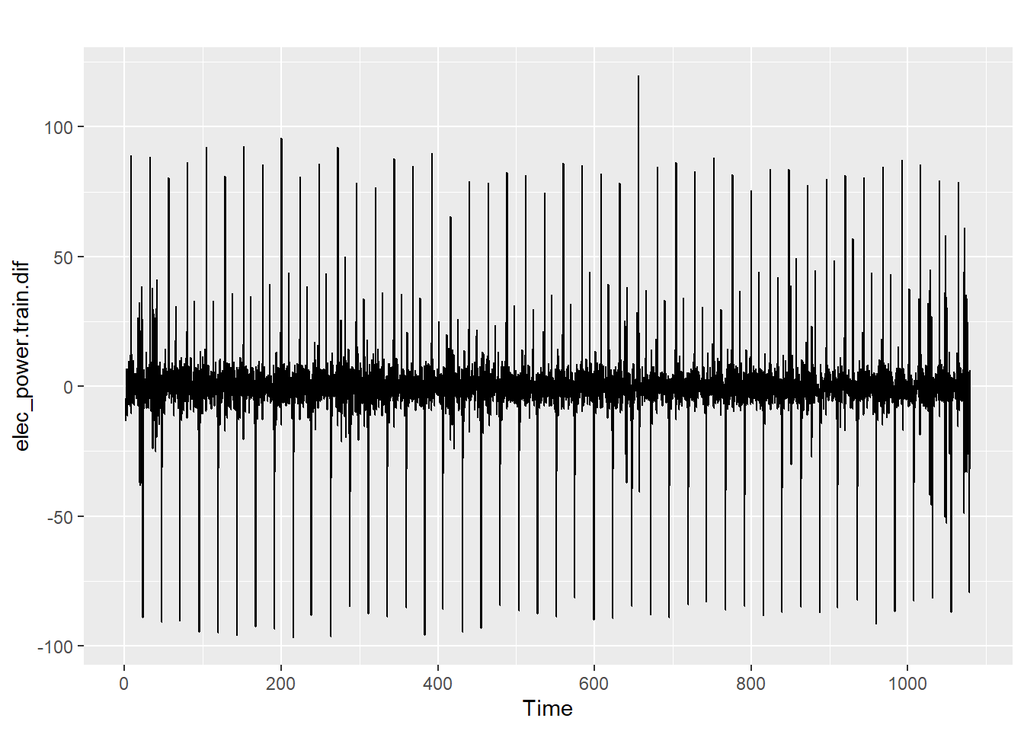

```r
# removing the trend
elec_power.train.dif <- diff(elec_power_train)
autoplot(elec_power.train.dif)
```

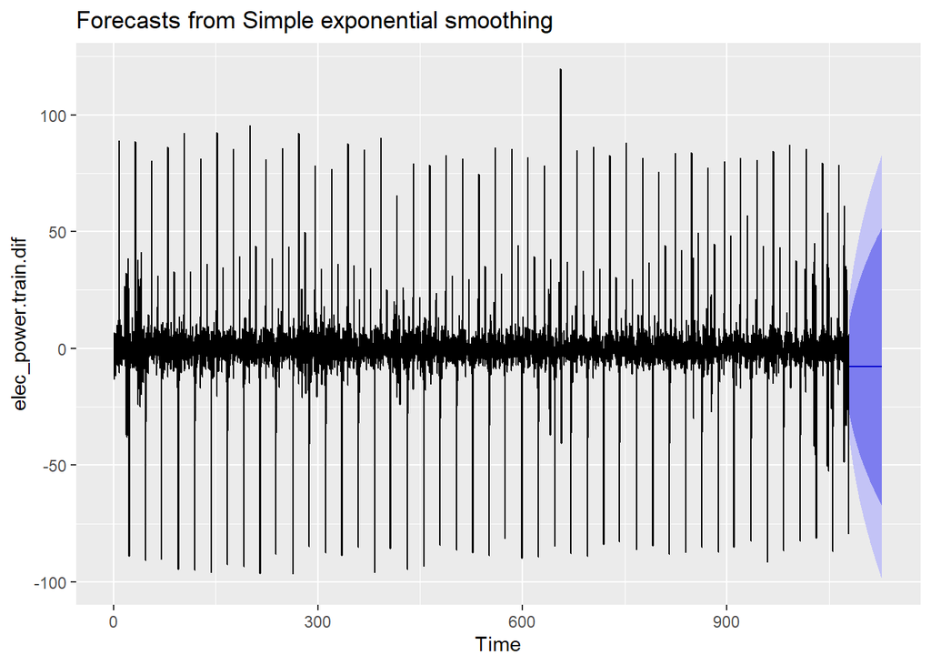

```r
# reapplying SES on the filtered data
SES.diff=ses(elec_power.train.dif,h=192 ,alpha = .2)

autoplot(SES.diff)
```

Afin de comprendre les performances de notre modèle, nous devons comparer nos prévisions avec notre ensemble de données de test.Puisque notre ensemble de données train a été différencié, nous devons également créer un ensemble de test différencié.

```r
# removing trend from test set
elec_power.dif.test <- diff(elec_power_test)
accuracy(SES.diff, elec_power.dif.test)
```

```
##                        ME     RMSE       MAE      MPE     MAPE      MASE
## Training set -0.006594403 15.81522  8.484059      NaN      Inf 0.7476761
## Test set      7.861902173 20.57925 14.675011 7.054971 397.5033 1.2932671
##                    ACF1 Theil's U
## Training set -0.1612523        NA
## Test set     -0.2381809 0.8725684
```

```r
# comparing our model
alpha <- seq(.01, .99, by = .01)
RMSE <- NA
for(i in seq_along(alpha)) {
  fit <- ses(elec_power.train.dif, alpha = alpha[i],
             h = 192)
  RMSE[i] <- accuracy(fit,
                      elec_power.dif.test)[2,2]
}

# convert to a data frame and
# identify min alpha value
alpha.fit <- data_frame(alpha, RMSE)
```

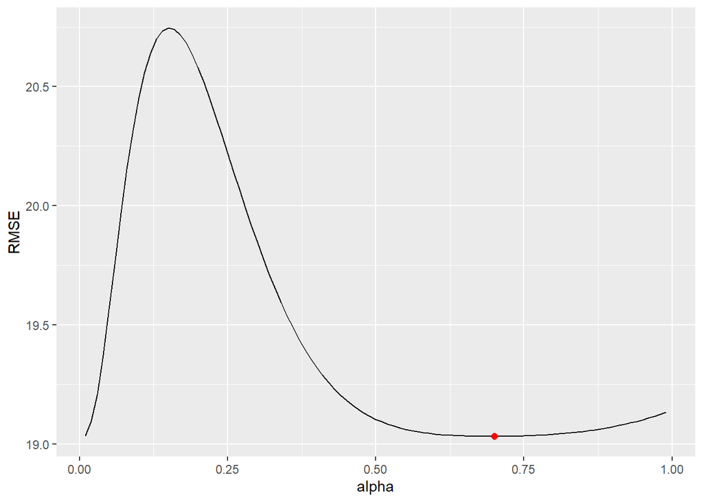

```r
alpha.min <- filter(alpha.fit,
                    RMSE == min(RMSE))

# plot RMSE vs. alpha
ggplot(alpha.fit, aes(alpha, RMSE)) +
  geom_line() +
  geom_point(data = alpha.min,
             aes(alpha, RMSE),
             size = 2, color = "red")
```

Nous remarquerons que environs 0,7 minimisera le plus.

Maintenant, nous allons essayer de réajuster notre modèle de prévision pour le SES avec alpha = 0,7.

```r
# refit model with alpha = .7
SES.opt=ses(elec_power.train.dif,h=192 ,alpha = .7)
round(accuracy(SES.opt,elec_power.dif.test),2)
```

```
##                ME  RMSE   MAE  MPE   MAPE MASE  ACF1 Theil's U
## Training set 0.00 18.84 10.31  NaN    Inf 0.91 -0.41        NA
## Test set     0.71 19.03 11.60 91.3 108.73 1.02 -0.24      0.98
```

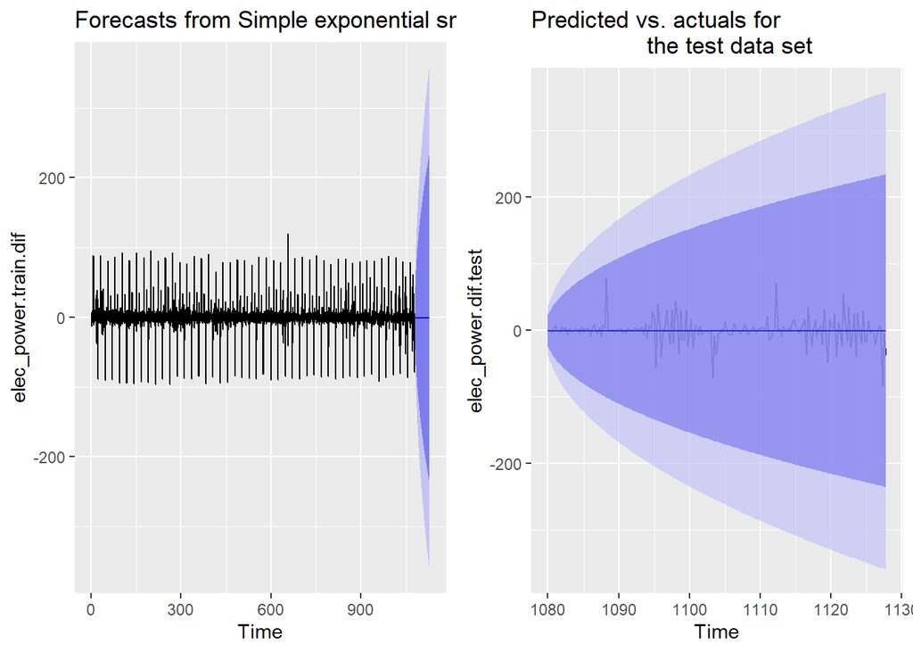

```r
# plotting results
p1 <- autoplot(SES.opt) +
  theme(legend.position = "bottom")
p2 <- autoplot(elec_power.dif.test) +
  autolayer(SES.opt, alpha = .7) +
  ggtitle("Predicted vs. actuals for
                 the test data set")

gridExtra::grid.arrange(p1, p2,
                        nrow = 1)
```

# Méthode de Holt

Nous avons vu qu’en SES, nous avons dû supprimer les tendances à long terme pour améliorer le modèle. Mais dans la méthode de Holt, nous pouvons appliquer un lissage exponentiel tout en capturant les tendances dans les données. Cependat Il s’agit d’une technique qui fonctionne avec des données présentant une tendance mais pas de saisonnalité.

```r
# Forecasting with a Holt
HOLT=holt(elec_power_train,h=192,alpha=NULL,beta=NULL)
round(accuracy(HOLT,elec_power_test),2)
```

```
##                 ME  RMSE   MAE   MPE  MAPE MASE ACF1 Theil's U
## Training set -0.01 15.14  7.04 -0.24  3.22 0.44 0.00        NA
## Test set     75.03 95.58 76.13 27.17 27.90 4.71 0.94      4.31
```

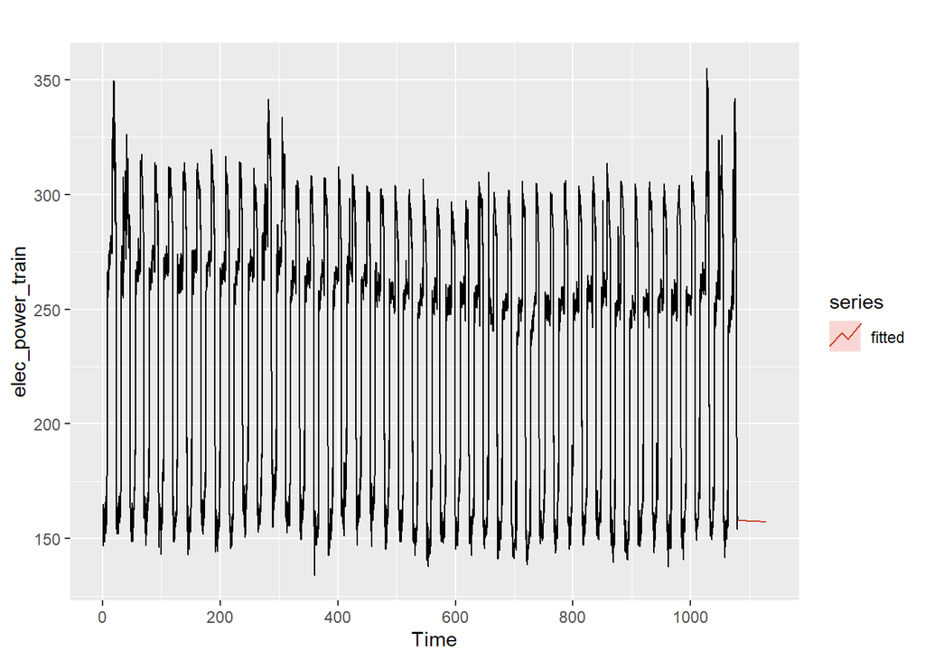

```r
autoplot(elec_power_train) + autolayer(HOLT,series='fitted',PI=FALSE)
```

Le modèle n’est pas adapté

# Holt-Winter’s Seasonal Method

cette methode est utilisée pour les données présentant à la fois des tendances et des tendances saisonnières. Cette méthode peut être implémentée soit en utilisant la structure additive, soit en utilisant la structure multiplicative en fonction de l’ensemble de données.

Le modèle additif est utilisé lorsque la tendance saisonnière des données a la même ampleur ou est constante tout au long de la période, tandis que le modèle multiplicatif est utilisé si l’ampleur de la tendance saisonnière des données augmente avec le temps.

```r
#Additive seasonal Holt-Winters
fit1=hw(elec_power_train,  seasonal = "additive",h=192)

#Multiplicative seasonal Holt-Winters
fit2 = hw(elec_power_train, seasonal='multiplicative',h=192)
```

# Damping Method

La méthode d’amortissement utilise le coefficient d’amortissement phi pour estimer de manière plus prudente les tendances prévues. La valeur de phi se situe entre 0 et 1. Si nous croyons que notre modèle additif et multiplicatif va être une ligne plate, alors il y a de fortes chances qu’il soit amorti.

```r
#Damped additive seasonal Holt-Winters
fit3 = hw(elec_power_train, seasonal='additive',h=192,damped=TRUE)

#Damped multiplicative seasonal Holt-Winters
fit4 = hw(elec_power_train,seasonal='multiplicative',h=192,damped=TRUE)
```

# Les prévisions

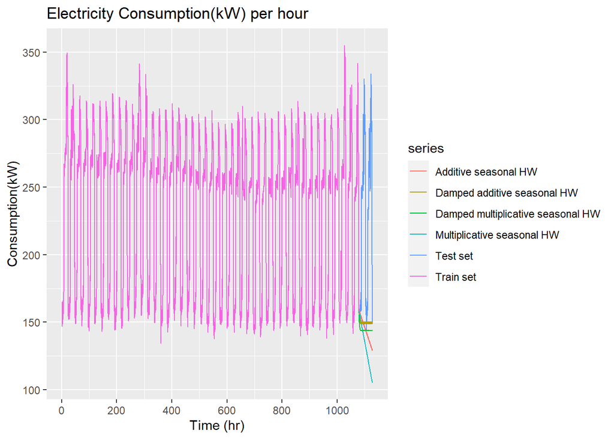

```r
# Plot all  models
autoplot(elec_power_train,series="Train set") +
  autolayer(elec_power_test,series='Test set')+
  autolayer(fit1$mean,series='Additive seasonal HW')+
  autolayer(fit2$mean,series='Multiplicative seasonal HW')+
  autolayer(fit3$mean,series='Damped additive seasonal HW')+
  autolayer(fit4$mean,series='Damped multiplicative seasonal HW')+
  ggtitle ('Electricity Consumption(kW) per hour') +
  xlab('Time (hr)') +
  ylab('Consumption(kW)')
```

```r
#RMSE
cat('Additive seasonal: RMSE Test set = ',sqrt(mean((fit1$mean-elec_power_test)^2)),'\n')
```

```
## Additive seasonal: RMSE Test set =  108.8472
```

```r
cat('Multiplicative seasonal: RMSE Test set =',sqrt(mean((fit2$mean-elec_power_test)^2)),'\n')
```

```
## Multiplicative seasonal: RMSE Test set = 121.1528
```

```r
cat('Damped additive seasonal: RMSE Test set=',sqrt(mean((fit3$mean-elec_power_test)^2)),'\n')
```

```
## Damped additive seasonal: RMSE Test set= 101.9794
```

```r
cat('Damped multiplicative seasonal: RMSE Test set=',sqrt(mean((fit4$mean-elec_power_test)^2)),'\n')
```

```
## Damped multiplicative seasonal: RMSE Test set= 106.6134
```

On conclue que pour l’instant le meilleur modèle est SES.opt , présentant l’erreur la plus faible avec un RMSE=19.03.

# **Forecasting with ARMA models**